# Predictors of Job Satisfaction and Employee Performance

> **Problem**  
> A team of professionals working in the field of Work Psychology has requested your collaboration for data analysis. The team collected information on a sample of 300 employees from a company that provides technological solutions to small and medium-sized businesses. One of their main interests is to identify predictors of job satisfaction and employee performance based on demographic, organizational, and clinical variables. Additionally, they seek your assistance in analyzing possible associations, correlations, and significant differences considering specific variables.

```r
library(tidyverse)
library(psych)
library(skimr)
library(readxl)
library(expss)
library(ggplot2)
library(rcompanion)
library(rstatix)
library(apa)
library(olsrr)
library(MASS)
library(car)
library(pROC)
library(oddsratio)
library(caret)

BaseTrabajo <- read_xlsx("Psi_Trabajo.xlsx")
```

# 1. Identify the type and level of measurement of each variable included in the database.

```r
BaseTrabajo$Home_office <- as.factor(BaseTrabajo$Home_office)
BaseTrabajo$Genero_femenino <- as.factor(BaseTrabajo$Genero_femenino)
BaseTrabajo$Tipo_de_trabajo <- as.factor(BaseTrabajo$Tipo_de_trabajo)
BaseTrabajo$Rendimiento <- as.factor(BaseTrabajo$Rendimiento)
skim(BaseTrabajo)
```

Data summary

| Name | BaseTrabajo |
| --- | --- |
| Number of rows | 300 |
| Number of columns | 14 |
| _______________________ |  |
| Column type frequency: |  |
| character | 1 |
| factor | 4 |
| numeric | 9 |
| ________________________ |  |
| Group variables | None |

**Variable type: character**

| skim_variable | n_missing | complete_rate | min | max | empty | n_unique | whitespace |
| --- | --- | --- | --- | --- | --- | --- | --- |
| ID_empleado | 0 | 1 | 1 | 3 | 0 | 300 | 0 |

**Variable type: factor**

| skim_variable | n_missing | complete_rate | ordered | n_unique | top_counts |
| --- | --- | --- | --- | --- | --- |
| Home_office | 0 | 1 | FALSE | 2 | 1: 158, 0: 142 |
| Genero_femenino | 0 | 1 | FALSE | 2 | 0: 173, 1: 127 |
| Tipo_de_trabajo | 0 | 1 | FALSE | 4 | 2: 107, 4: 97, 3: 53, 1: 43 |
| Rendimiento | 0 | 1 | FALSE | 2 | 0: 158, 1: 142 |

**Variable type: numeric**

| skim_variable | n_missing | complete_rate | mean | sd | p0 | p25 | p50 | p75 | p100 | hist |
| --- | --- | --- | --- | --- | --- | --- | --- | --- | --- | --- |
| Satisfaccion_laboral | 0 | 1 | 50.00 | 10.00 | 19.52 | 43.43 | 49.31 | 56.14 | 81.28 | ▁▃▇▃▁ |
| Flexibilidad_cognitiva | 0 | 1 | 70.00 | 15.00 | 13.36 | 60.78 | 70.40 | 79.34 | 108.39 | ▁▂▇▇▂ |
| Percepcion_ambiente_laboral | 0 | 1 | 60.00 | 12.00 | 10.54 | 51.99 | 59.72 | 67.81 | 89.75 | ▁▁▇▇▂ |
| Autoestima | 0 | 1 | 80.00 | 18.00 | 22.96 | 67.10 | 78.93 | 93.61 | 130.09 | ▁▃▇▅▁ |
| Perspectiva_laboral_futura | 0 | 1 | 55.00 | 8.00 | 35.29 | 48.92 | 55.08 | 60.99 | 75.92 | ▂▇▇▆▁ |
| Ansiedad | 0 | 1 | 75.00 | 10.00 | 48.49 | 67.61 | 74.99 | 81.63 | 105.64 | ▁▆▇▃▁ |
| Depresion | 0 | 1 | 65.00 | 11.00 | 36.39 | 57.87 | 64.87 | 71.66 | 110.23 | ▂▇▆▁▁ |
| Inteligencia | 0 | 1 | 100.41 | 15.48 | 59.44 | 90.26 | 99.06 | 109.64 | 150.78 | ▁▆▇▂▁ |
| Red_social | 0 | 1 | 42.42 | 15.94 | -1.82 | 31.53 | 42.06 | 53.46 | 82.95 | ▁▅▇▆▂ |

# 2. Perform a descriptive analysis of the different variables included in the dataset—excluding the ID. Calculate the corresponding descriptive statistics in each case and report the results.

## Job satisfaction

```r
describe(BaseTrabajo$Satisfaccion_laboral)
```

```
##    vars   n mean sd median trimmed mad   min   max range skew kurtosis   se
## X1    1 300   50 10  49.31    49.9 9.1 19.52 81.28 61.76 0.12     0.19 0.58
```

> The sample has a mean job satisfaction score of 50 (SD = 10).

## Cognitive flexibility

```r
describe(BaseTrabajo$Flexibilidad_cognitiva)
```

```
##    vars   n mean sd median trimmed   mad   min    max range skew kurtosis   se
## X1    1 300   70 15   70.4   70.02 13.86 13.36 108.39 95.03 -0.2     0.55 0.87
```

> The sample has a mean cognitive flexibility score of 70 (SD = 15).

## Perception of work environment

```r
describe(BaseTrabajo$Percepcion_ambiente_laboral)
```

```
##    vars   n mean sd median trimmed   mad   min   max range  skew kurtosis   se
## X1    1 300   60 12  59.72   59.91 11.85 10.54 89.75 79.21 -0.05     0.39 0.69
```

> The sample has a mean work environment perception score of 60 (SD = 12).

## Self-esteem

```r
describe(BaseTrabajo$Autoestima)
```

```
##    vars   n mean sd median trimmed   mad   min    max  range skew kurtosis   se
## X1    1 300   80 18  78.93   79.71 19.06 22.96 130.09 107.13 0.06        0 1.04
```

> The sample has a mean self-esteem score of 80 (SD = 18).

## Future career outlook

```r
describe(BaseTrabajo$Perspectiva_laboral_futura)
```

```
##    vars   n mean sd median trimmed  mad   min   max range skew kurtosis   se
## X1    1 300   55  8  55.08    54.9 8.94 35.29 75.92 40.64 0.08    -0.53 0.46
```

> The sample has a mean score for future job perspective of 55 (SD = 8).

## Anxiety

```r
describe(BaseTrabajo$Ansiedad)
```

```
##    vars   n mean sd median trimmed   mad   min    max range skew kurtosis   se
## X1    1 300   75 10  74.99   74.83 10.54 48.49 105.64 57.14 0.13    -0.17 0.58
```

> The sample has a mean score for anxiety of 75 (SD = 10).

## Depresion

```r
describe(BaseTrabajo$Depresion)
```

```
##    vars   n mean sd median trimmed   mad   min    max range skew kurtosis   se
## X1    1 300   65 11  64.87   64.83 10.34 36.39 110.23 73.84 0.25     0.47 0.64
```

> The sample has a mean score for depression of 65 (SD = 11).

## Intelligence

```r
describe(BaseTrabajo$Inteligencia)
```

```
##    vars   n   mean    sd median trimmed   mad   min    max range skew kurtosis
## X1    1 300 100.41 15.48  99.06   99.95 14.45 59.44 150.78 91.34 0.33     0.35
##      se
## X1 0.89
```

> The sample has a mean score for intelligence of 100.41 (SD = 15.48).

## Social network

```r
describe(BaseTrabajo$Red_social)
```

```
##    vars   n  mean    sd median trimmed   mad   min   max range skew kurtosis
## X1    1 300 42.42 15.94  42.06   42.41 16.44 -1.82 82.95 84.77    0    -0.31
##      se
## X1 0.92
```

> The sample has a mean score for social network of 42.42 (SD = 15.94).

## Home office

```r
fre(BaseTrabajo$Home_office)
```

| BaseTrabajo$Home_office | Count | Valid percent | Percent | Responses, % | Cumulative responses, % |
| --- | --- | --- | --- | --- | --- |
| 0 | 142 | 47.3 | 47.3 | 47.3 | 47.3 |
| 1 | 158 | 52.7 | 52.7 | 52.7 | 100.0 |
| #Total | 300 | 100 | 100 | 100 |  |
| <NA> | 0 |  | 0.0 |  |  |

> The mode for the variable “home office” is working from home. 52.7% of participants reported working from home, while 47.3% do not work under this modality.

## Gender

```r
fre(BaseTrabajo$Genero_femenino)
```

| BaseTrabajo$Genero_femenino | Count | Valid percent | Percent | Responses, % | Cumulative responses, % |
| --- | --- | --- | --- | --- | --- |
| 0 | 173 | 57.7 | 57.7 | 57.7 | 57.7 |
| 1 | 127 | 42.3 | 42.3 | 42.3 | 100.0 |
| #Total | 300 | 100 | 100 | 100 |  |
| <NA> | 0 |  | 0.0 |  |  |

> The mode for the variable “gender” is male. 57.7% of participants reported identifying as male, while 42.3% identified as female.

## Job type

(1 = Marketing; 2 = Programadores; 3 = Atención al cliente; 4 = Ventas)

```r
fre(BaseTrabajo$Tipo_de_trabajo)
```

| BaseTrabajo$Tipo_de_trabajo | Count | Valid percent | Percent | Responses, % | Cumulative responses, % |
| --- | --- | --- | --- | --- | --- |
| 1 | 43 | 14.3 | 14.3 | 14.3 | 14.3 |
| 2 | 107 | 35.7 | 35.7 | 35.7 | 50.0 |
| 3 | 53 | 17.7 | 17.7 | 17.7 | 67.7 |
| 4 | 97 | 32.3 | 32.3 | 32.3 | 100.0 |
| #Total | 300 | 100 | 100 | 100 |  |
| <NA> | 0 |  | 0.0 |  |  |

> The mode for the variable “type of work” is programmer. 35.7% of participants reported being programmers, 32.3% work in sales, 17.7% in customer service, and 14.3% in marketing.

## Performance

```r
fre(BaseTrabajo$Rendimiento)
```

| BaseTrabajo$Rendimiento | Count | Valid percent | Percent | Responses, % | Cumulative responses, % |
| --- | --- | --- | --- | --- | --- |
| 0 | 158 | 52.7 | 52.7 | 52.7 | 52.7 |
| 1 | 142 | 47.3 | 47.3 | 47.3 | 100.0 |
| #Total | 300 | 100 | 100 | 100 |  |
| <NA> | 0 |  | 0.0 |  |  |

> The mode for the variable “performance” is insufficient. 52.7% of participants reported an insufficient performance level, while 47.3% reported a sufficient performance level.

# 3. Plot the variables “Anxiety,” “Depression,” “Intelligence,” “Home_office,” and “Job_type.” For the last two variables, also create tables for absolute and relative frequency distribution.

## Anxiety

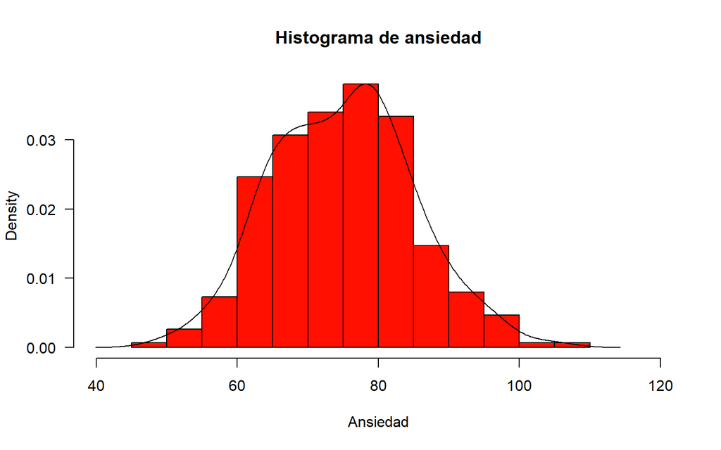

```r
hist(BaseTrabajo$Ansiedad,
     main="Histograma de ansiedad",
     xlab="Ansiedad",
     freq=F,
     border="black",
     col="#FF1000",
     xlim=c(40,120),
     las=1,
     breaks=20)
lines(density(BaseTrabajo$Ansiedad, na.rm=T))
```

## Depresion

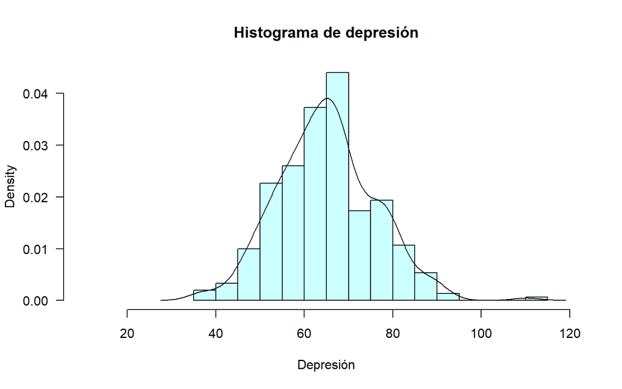

```r
hist(BaseTrabajo$Depresion,
     main="Histograma de depresión",
     xlab="Depresión",
     freq=F,
     border="black",
     col="#CCFFFF",
     xlim=c(10,120),
     las=1,
     breaks=20)
lines(density(BaseTrabajo$Depresion, na.rm=T))
```

## Intelligence

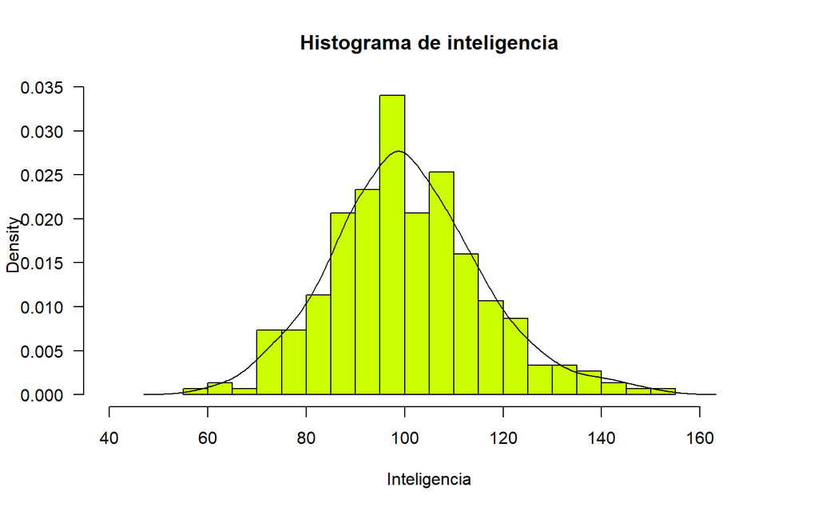

```r
hist(BaseTrabajo$Inteligencia,
     main="Histograma de inteligencia",
     xlab="Inteligencia",
     freq=F,
     border="black",
     col="#CCFF00",
     xlim=c(40,170),
     las=1,
     breaks=20)
lines(density(BaseTrabajo$Inteligencia, na.rm=T))
```

## Home office

### Graph

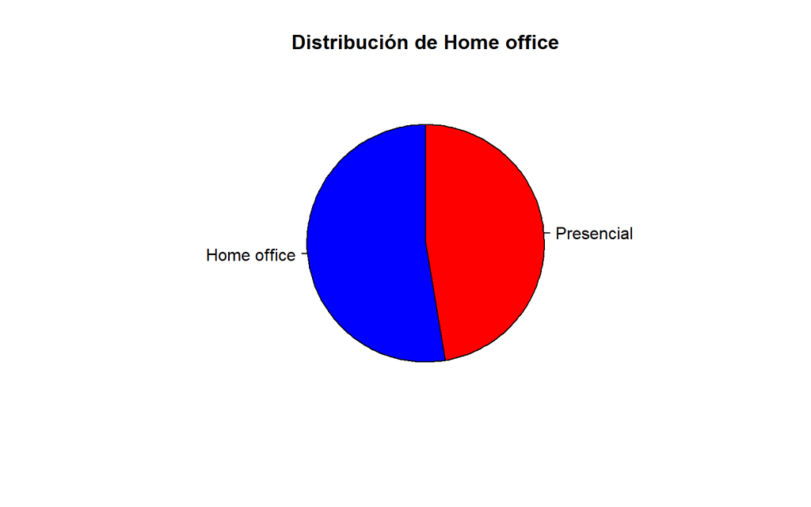

```r
pie(table(BaseTrabajo$Home_office),
    main="Distribución de Home office",
    col=c("red","blue"),
    border="black",
    clockwise=TRUE,
    labels = c("Presencial", "Home office"))
```

### Frequency table

```r
TableLabs <- BaseTrabajo
val_lab(TableLabs$Home_office) <- make_labels("
                                     0 No
                                     1 Sí")
fre(TableLabs$Home_office)
```

| TableLabs$Home_office | Count | Valid percent | Percent | Responses, % | Cumulative responses, % |
| --- | --- | --- | --- | --- | --- |
| No | 142 | 47.3 | 47.3 | 47.3 | 47.3 |
| Sí | 158 | 52.7 | 52.7 | 52.7 | 100.0 |
| #Total | 300 | 100 | 100 | 100 |  |
| <NA> | 0 |  | 0.0 |  |  |

## Job type

### Graph

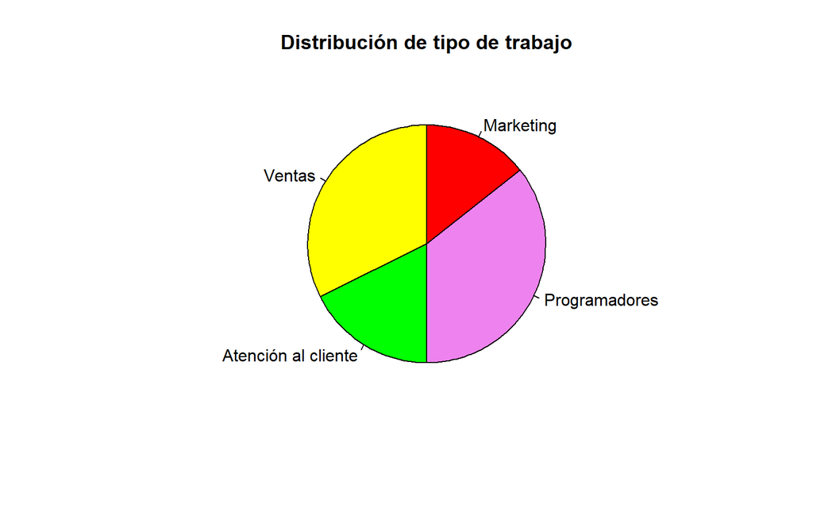

```r
pie(table(BaseTrabajo$Tipo_de_trabajo),
    main="Distribución de tipo de trabajo",
    col=c("red","violet","green","yellow"),
    border="black",
    clockwise=TRUE,
    labels = c("Marketing", "Programadores", "Atención al cliente","Ventas"))
```

### Frequency table

```r
val_lab(TableLabs$Tipo_de_trabajo) <- make_labels("
                                     1 Marketing
                                     2 Programación
                                     3 Atención al cliente
                                     4 Ventas")
fre(TableLabs$Tipo_de_trabajo)
```

| TableLabs$Tipo_de_trabajo | Count | Valid percent | Percent | Responses, % | Cumulative responses, % |
| --- | --- | --- | --- | --- | --- |
| Marketing | 43 | 14.3 | 14.3 | 14.3 | 14.3 |
| Programación | 107 | 35.7 | 35.7 | 35.7 | 50.0 |
| Atención al cliente | 53 | 17.7 | 17.7 | 17.7 | 67.7 |
| Ventas | 97 | 32.3 | 32.3 | 32.3 | 100.0 |
| #Total | 300 | 100 | 100 | 100 |  |
| <NA> | 0 |  | 0.0 |  |  |

# 4. Create a contingency table for the variables “Job_type” and “Female_gender” and analyze whether there is an association between these variables. Interpret and report the results.

```r
con1 <- table(BaseTrabajo$Tipo_de_trabajo,BaseTrabajo$Genero_femenino)
addmargins(prop.table(con1))
```

```
##
##                0          1        Sum
##   1   0.06666667 0.07666667 0.14333333
##   2   0.19666667 0.16000000 0.35666667
##   3   0.11000000 0.06666667 0.17666667
##   4   0.20333333 0.12000000 0.32333333
##   Sum 0.57666667 0.42333333 1.00000000
```

```r
chisq.test(con1)
```

```
##
##  Pearson's Chi-squared test
##
## data:  con1
## X-squared = 4.0131, df = 3, p-value = 0.26
```

> **Since both variables are qualitative and all groups have frequencies above 5%, a chi-square test was conducted. No association was observed between job type and gender (p = .26). There is evidence supporting the independence of these variables.**

# 5. Repeat the previous step for the variables “Job_type” and “Performance.” Interpret and report the results.

```r
con2 <- table(BaseTrabajo$Tipo_de_trabajo,BaseTrabajo$Rendimiento)
addmargins(prop.table(con2))
```

```
##
##               0         1       Sum
##   1   0.0400000 0.1033333 0.1433333
##   2   0.1666667 0.1900000 0.3566667
##   3   0.1266667 0.0500000 0.1766667
##   4   0.1933333 0.1300000 0.3233333
##   Sum 0.5266667 0.4733333 1.0000000
```

```r
cramerV(con2, ci=TRUE)
```

```
##   Cramer.V lower.ci upper.ci
## 1   0.2693   0.1864   0.3799
```

> **Since both variables are qualitative and not all groups have frequencies above 5%, a Cramér’s V test was conducted. There is evidence supporting the existence of a moderate association between the variables.**

# 6. Analyze whether each of the quantitative variables follows a normal distribution.

## Job satisfaction

```r
shapiro.test(BaseTrabajo$Satisfaccion_laboral)
```

```
##
##  Shapiro-Wilk normality test
##
## data:  BaseTrabajo$Satisfaccion_laboral
## W = 0.9966, p-value = 0.7753
```

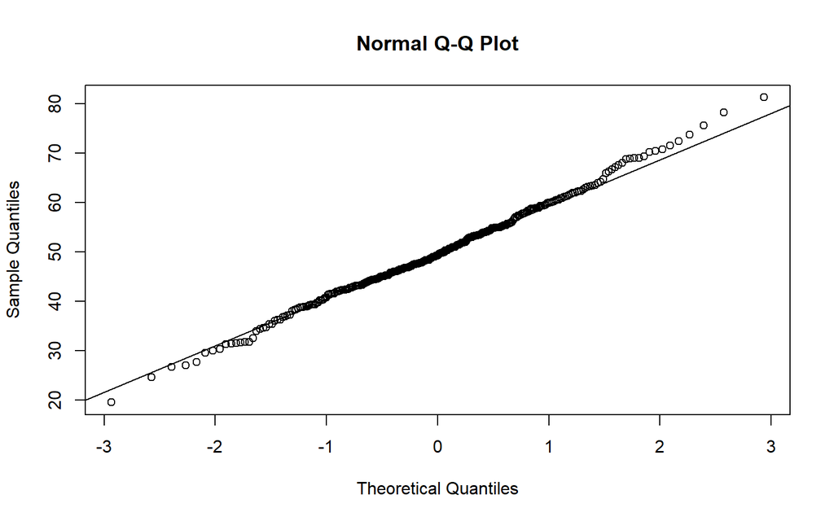

```r
qqnorm(BaseTrabajo$Satisfaccion_laboral)
qqline(BaseTrabajo$Satisfaccion_laboral)
```

> **Based on statistical tests and graphical techniques, sufficient evidence was found to support a normal distribution for the variable job satisfaction.**

## Cognitive flexibility

```r
shapiro.test(BaseTrabajo$Flexibilidad_cognitiva)
```

```
##
##  Shapiro-Wilk normality test
##
## data:  BaseTrabajo$Flexibilidad_cognitiva
## W = 0.99179, p-value = 0.09451
```

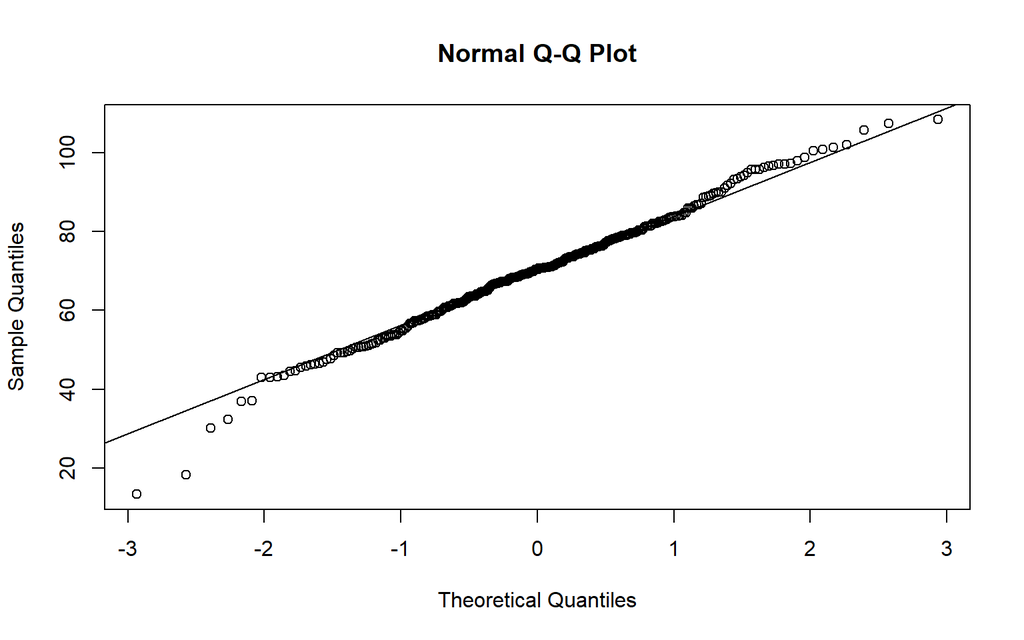

```r
qqnorm(BaseTrabajo$Flexibilidad_cognitiva)
qqline(BaseTrabajo$Flexibilidad_cognitiva)
```

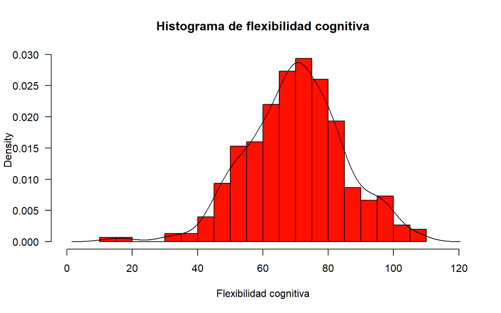

```r
hist(BaseTrabajo$Flexibilidad_cognitiva,
     main="Histograma de flexibilidad cognitiva",
     xlab="Flexibilidad cognitiva",
     freq=F,
     border="black",
     col="#FF1000",
     xlim=c(0,120),
     las=1,
     breaks=20)
lines(density(BaseTrabajo$Flexibilidad_cognitiva, na.rm=T))
```

> **Based on statistical tests and graphical techniques, sufficient evidence was found to support a normal distribution for the variable cognitive flexibility. Additionally, a couple of outliers were identified.**

## Perception of the work environment

```r
shapiro.test(BaseTrabajo$Percepcion_ambiente_laboral)
```

```
##
##  Shapiro-Wilk normality test
##
## data:  BaseTrabajo$Percepcion_ambiente_laboral
## W = 0.99225, p-value = 0.1196
```

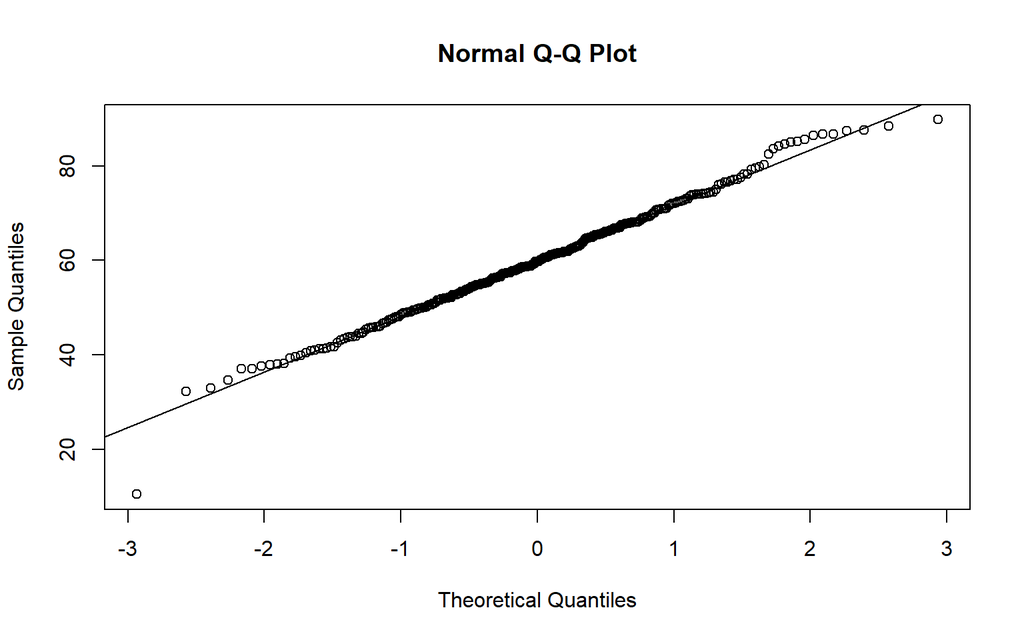

```r
qqnorm(BaseTrabajo$Percepcion_ambiente_laboral)
qqline(BaseTrabajo$Percepcion_ambiente_laboral)
```

> **Based on statistical tests and graphical techniques, sufficient evidence was found to support a normal distribution for the variable work environment.**

## Self-esteem

```r
shapiro.test(BaseTrabajo$Autoestima)
```

```
##
##  Shapiro-Wilk normality test
##
## data:  BaseTrabajo$Autoestima
## W = 0.99366, p-value = 0.2397
```

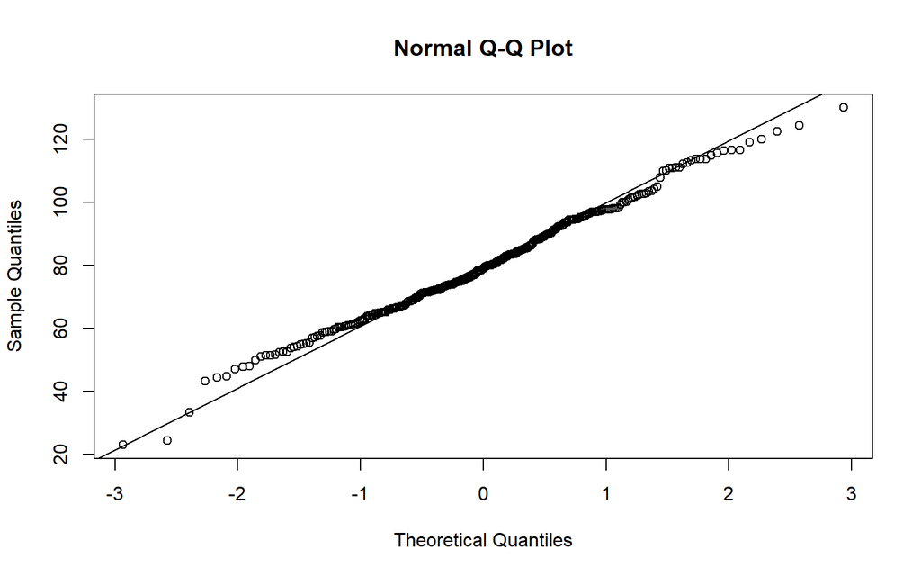

```r
qqnorm(BaseTrabajo$Autoestima)
qqline(BaseTrabajo$Autoestima)
```

> **Based on statistical tests and graphical techniques, sufficient evidence was found to support a normal distribution for the variable self-esteem.**

## Future job outlook

```r
shapiro.test(BaseTrabajo$Perspectiva_laboral_futura)
```

```
##
##  Shapiro-Wilk normality test
##
## data:  BaseTrabajo$Perspectiva_laboral_futura
## W = 0.99359, p-value = 0.2317
```

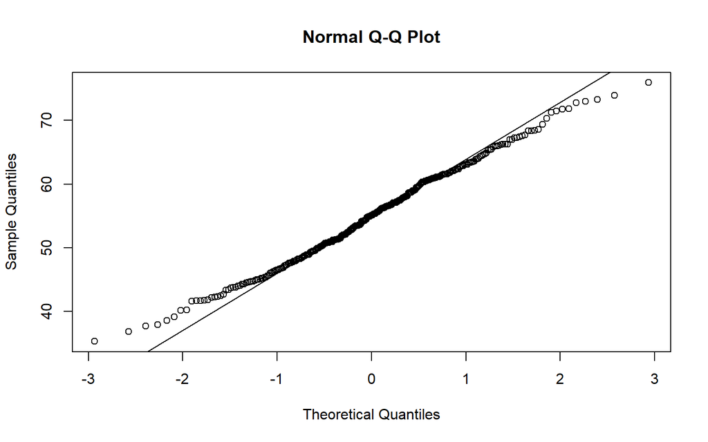

```r
qqnorm(BaseTrabajo$Perspectiva_laboral_futura)
qqline(BaseTrabajo$Perspectiva_laboral_futura)
```

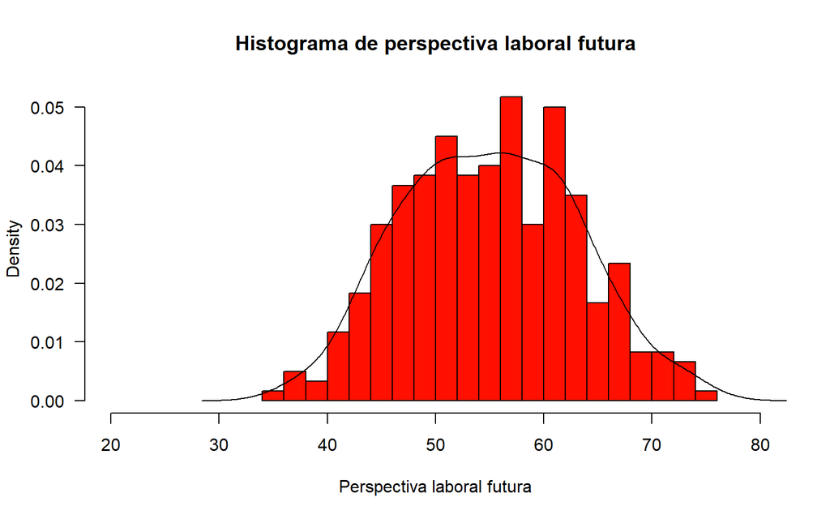

```r
hist(BaseTrabajo$Perspectiva_laboral_futura,
     main="Histograma de perspectiva laboral futura",
     xlab="Perspectiva laboral futura",
     freq=F,
     border="black",
     col="#FF1000",
     xlim=c(20,80),
     las=1,
     breaks=20)
lines(density(BaseTrabajo$Perspectiva_laboral_futura, na.rm=T))
```

> **Based on statistical tests and graphical techniques, sufficient evidence was found to support a normal distribution for the variable future job outlook.**

## Anxiety

```r
shapiro.test(BaseTrabajo$Ansiedad)
```

```
##
##  Shapiro-Wilk normality test
##
## data:  BaseTrabajo$Ansiedad
## W = 0.9963, p-value = 0.7108
```

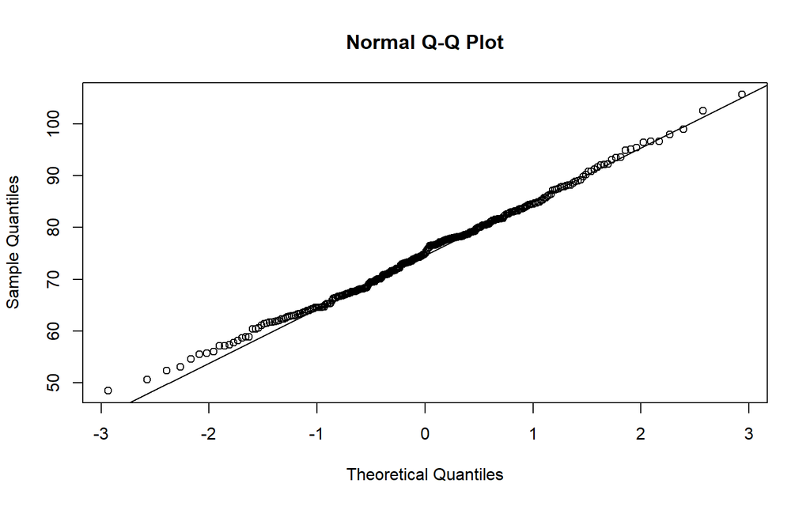

```r
qqnorm(BaseTrabajo$Ansiedad)
qqline(BaseTrabajo$Ansiedad)
```

> **Based on statistical tests and graphical techniques, sufficient evidence was found to support a normal distribution for the variable anxiety.**

## Depresion

```r
shapiro.test(BaseTrabajo$Depresion)
```

```
##
##  Shapiro-Wilk normality test
##
## data:  BaseTrabajo$Depresion
## W = 0.99235, p-value = 0.1257
```

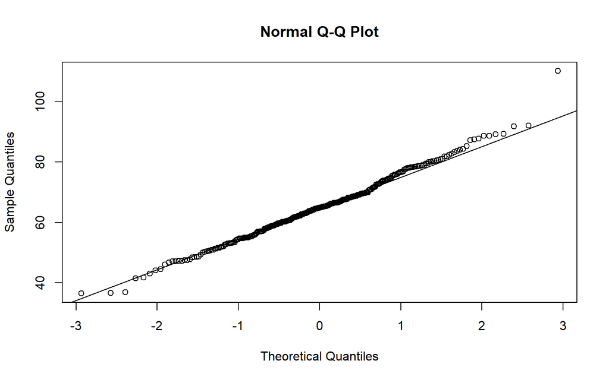

```r
qqnorm(BaseTrabajo$Depresion)
qqline(BaseTrabajo$Depresion)
```

> **Based on statistical tests and graphical techniques, sufficient evidence was found to support a normal distribution for the variable depression. Additionally, an outlier was identified.**

## Intelligence

```r
shapiro.test(BaseTrabajo$Inteligencia)
```

```
##
##  Shapiro-Wilk normality test
##
## data:  BaseTrabajo$Inteligencia
## W = 0.99123, p-value = 0.07104
```

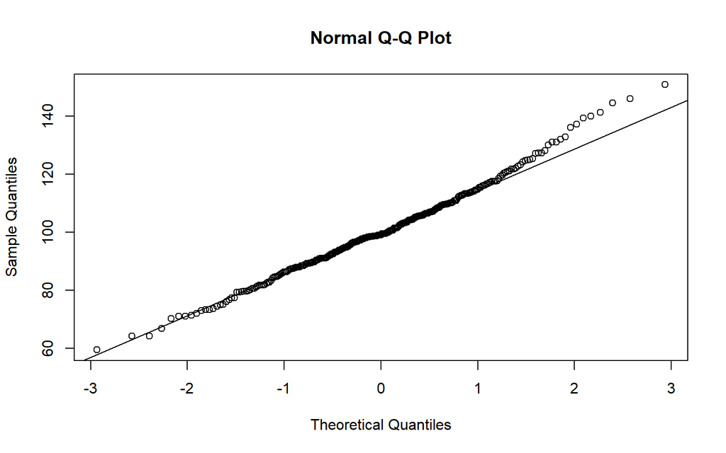

```r
qqnorm(BaseTrabajo$Inteligencia)
qqline(BaseTrabajo$Inteligencia)
```

> **Based on statistical tests and graphical techniques, sufficient evidence was found to support a normal distribution for the variable intelligence.**

## Social network

```r
shapiro.test(BaseTrabajo$Red_social)
```

```
##
##  Shapiro-Wilk normality test
##
## data:  BaseTrabajo$Red_social
## W = 0.99753, p-value = 0.9344
```

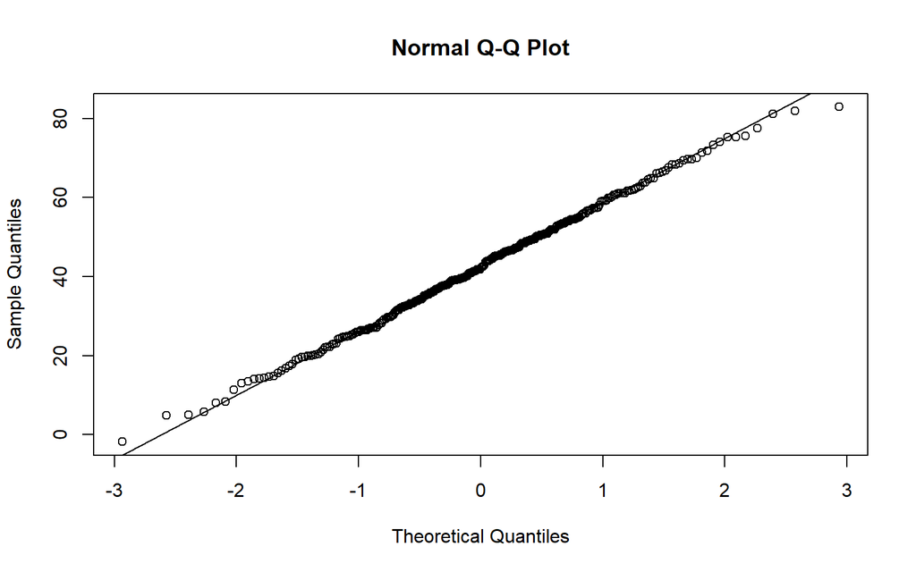

```r
qqnorm(BaseTrabajo$Red_social)
qqline(BaseTrabajo$Red_social)
```

> **Based on statistical tests and graphical techniques, sufficient evidence was found to support a normal distribution for the variable social network.**

# 7. Perform the analyses to determine if there are significant differences in job satisfaction (“Satisfaccion_laboral”) based on employees’ gender (“Genero_femenino”), whether they work in home office (“Home_office”), and their type of work (“Tipo_de_trabajo”). Evaluate the assumptions required for the corresponding parametric test. In case any assumption is violated, conduct the alternative non-parametric test. Interpret and report the results, including effect sizes, where appropriate.

## Job satisfaction by gender

```r
shapiro.test(BaseTrabajo$Satisfaccion_laboral[BaseTrabajo$Genero_femenino == "0"])
```

```
##
##  Shapiro-Wilk normality test
##
## data:  BaseTrabajo$Satisfaccion_laboral[BaseTrabajo$Genero_femenino == "0"]
## W = 0.99167, p-value = 0.4177
```

```r
shapiro.test(BaseTrabajo$Satisfaccion_laboral[BaseTrabajo$Genero_femenino == "1"])
```

```
##
##  Shapiro-Wilk normality test
##
## data:  BaseTrabajo$Satisfaccion_laboral[BaseTrabajo$Genero_femenino == "1"]
## W = 0.99525, p-value = 0.9508
```

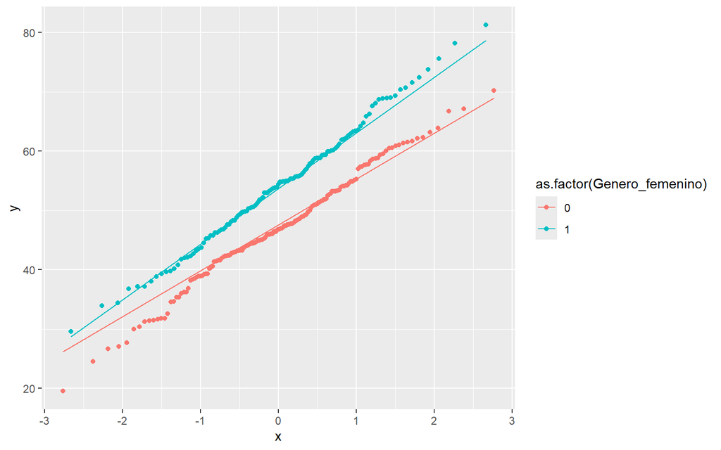

```r
ggplot(BaseTrabajo, aes(sample = Satisfaccion_laboral, colour = as.factor(Genero_femenino))) +
  stat_qq() +
  stat_qq_line()
```

```r
levene_test(data=BaseTrabajo,Satisfaccion_laboral~Genero_femenino)
```

```
## # A tibble: 1 × 4
##     df1   df2 statistic     p
##   <int> <int>     <dbl> <dbl>
## 1     1   298      2.04 0.155
```

```r
t.test(BaseTrabajo$Satisfaccion_laboral~BaseTrabajo$Genero_femenino)
```

```
##
##  Welch Two Sample t-test
##
## data:  BaseTrabajo$Satisfaccion_laboral by BaseTrabajo$Genero_femenino
## t = -6.396, df = 253.83, p-value = 7.621e-10
## alternative hypothesis: true difference in means between group 0 and group 1 is not equal to 0
## 95 percent confidence interval:
##  -9.317365 -4.930423
## sample estimates:
## mean in group 0 mean in group 1
##        46.98422        54.10811
```

```r
cohen.d(BaseTrabajo$Satisfaccion_laboral, BaseTrabajo$Genero_femenino)
```

```
## Call: cohen.d(x = BaseTrabajo$Satisfaccion_laboral, group = BaseTrabajo$Genero_femenino)
## Cohen d statistic of difference between two means
##      lower effect upper
## [1,]  0.52   0.76     1
##
## Multivariate (Mahalanobis) distance between groups
## [1] 0.76
## r equivalent of difference between two means
## data
## 0.35
```

```r
describe.by(BaseTrabajo$Satisfaccion_laboral, BaseTrabajo$Genero_femenino)
```

```
##
##  Descriptive statistics by group
## group: 0
##    vars   n  mean   sd median trimmed  mad   min   max range  skew kurtosis
## X1    1 173 46.98 8.92  46.82   47.15 7.67 19.52 70.24 50.73 -0.15     0.15
##      se
## X1 0.68
## ------------------------------------------------------------
## group: 1
##    vars   n  mean   sd median trimmed  mad   min   max range skew kurtosis   se
## X1    1 127 54.11 9.95  54.43   53.95 9.36 29.56 81.28 51.72 0.16    -0.19 0.88
```

## Job satisfaction by home office

```r
shapiro.test(BaseTrabajo$Satisfaccion_laboral[BaseTrabajo$Home_office == "0"])
```

```
##
##  Shapiro-Wilk normality test
##
## data:  BaseTrabajo$Satisfaccion_laboral[BaseTrabajo$Home_office == "0"]
## W = 0.99158, p-value = 0.5601
```

```r
shapiro.test(BaseTrabajo$Satisfaccion_laboral[BaseTrabajo$Home_office == "1"])
```

```
##
##  Shapiro-Wilk normality test
##
## data:  BaseTrabajo$Satisfaccion_laboral[BaseTrabajo$Home_office == "1"]
## W = 0.99561, p-value = 0.9232
```

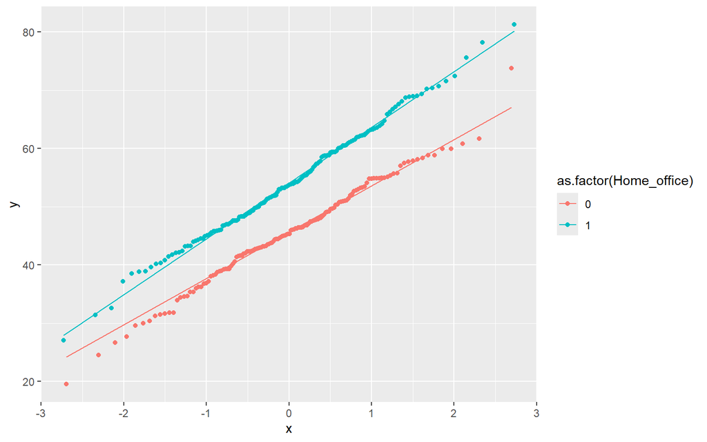

```r
ggplot(BaseTrabajo, aes(sample = Satisfaccion_laboral, colour = as.factor(Home_office))) +
  stat_qq() +
  stat_qq_line()
```

```r
levene_test(data=BaseTrabajo,Satisfaccion_laboral~Home_office)
```

```
## # A tibble: 1 × 4
##     df1   df2 statistic     p
##   <int> <int>     <dbl> <dbl>
## 1     1   298      1.99 0.160
```

```r
t.test(BaseTrabajo$Satisfaccion_laboral~BaseTrabajo$Home_office)
```

```
##
##  Welch Two Sample t-test
##
## data:  BaseTrabajo$Satisfaccion_laboral by BaseTrabajo$Home_office
## t = -8.3738, df = 297.98, p-value = 2.21e-15
## alternative hypothesis: true difference in means between group 0 and group 1 is not equal to 0
## 95 percent confidence interval:
##  -10.73181  -6.64745
## sample estimates:
## mean in group 0 mean in group 1
##        45.42346        54.11309
```

```r
cohen.d(BaseTrabajo$Satisfaccion_laboral, BaseTrabajo$Home_office)
```

```
## Call: cohen.d(x = BaseTrabajo$Satisfaccion_laboral, group = BaseTrabajo$Home_office)
## Cohen d statistic of difference between two means
##      lower effect upper
## [1,]  0.73   0.97  1.21
##
## Multivariate (Mahalanobis) distance between groups
## [1] 0.97
## r equivalent of difference between two means
## data
## 0.43
```

```r
describe.by(BaseTrabajo$Satisfaccion_laboral, BaseTrabajo$Home_office)
```

```
##
##  Descriptive statistics by group
## group: 0
##    vars   n  mean   sd median trimmed  mad   min   max range  skew kurtosis
## X1    1 142 45.42 8.54  45.31   45.61 8.28 19.52 73.78 54.27 -0.11     0.39
##      se
## X1 0.72
## ------------------------------------------------------------
## group: 1
##    vars   n  mean   sd median trimmed  mad   min   max range skew kurtosis   se
## X1    1 158 54.11 9.43   53.7   53.95 9.68 27.02 81.28 54.26 0.12        0 0.75
```

## Job satisfaction by job type

```r
shapiro.test(BaseTrabajo$Satisfaccion_laboral[BaseTrabajo$Tipo_de_trabajo == "1"])
```

```
##
##  Shapiro-Wilk normality test
##
## data:  BaseTrabajo$Satisfaccion_laboral[BaseTrabajo$Tipo_de_trabajo == "1"]
## W = 0.97059, p-value = 0.3313
```

```r
shapiro.test(BaseTrabajo$Satisfaccion_laboral[BaseTrabajo$Tipo_de_trabajo == "2"])
```

```
##
##  Shapiro-Wilk normality test
##
## data:  BaseTrabajo$Satisfaccion_laboral[BaseTrabajo$Tipo_de_trabajo == "2"]
## W = 0.99266, p-value = 0.8386
```

```r
shapiro.test(BaseTrabajo$Satisfaccion_laboral[BaseTrabajo$Tipo_de_trabajo == "3"])
```

```
##
##  Shapiro-Wilk normality test
##
## data:  BaseTrabajo$Satisfaccion_laboral[BaseTrabajo$Tipo_de_trabajo == "3"]
## W = 0.96278, p-value = 0.09742
```

```r
shapiro.test(BaseTrabajo$Satisfaccion_laboral[BaseTrabajo$Tipo_de_trabajo == "4"])
```

```
##
##  Shapiro-Wilk normality test
##
## data:  BaseTrabajo$Satisfaccion_laboral[BaseTrabajo$Tipo_de_trabajo == "4"]
## W = 0.98466, p-value = 0.3205
```

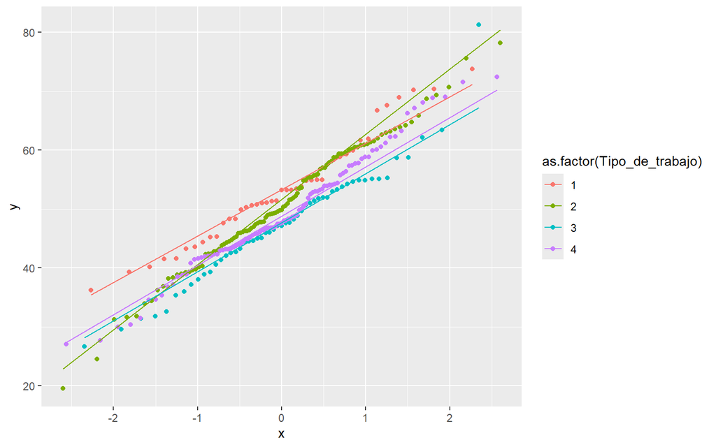

```r
ggplot(BaseTrabajo, aes(sample = Satisfaccion_laboral, colour = as.factor(Tipo_de_trabajo))) +
  stat_qq() +
  stat_qq_line()
```

```r
levene_test(data=BaseTrabajo,Satisfaccion_laboral~Tipo_de_trabajo)
```

```
## # A tibble: 1 × 4
##     df1   df2 statistic     p
##   <int> <int>     <dbl> <dbl>
## 1     3   296     0.854 0.466
```

```r
ANOVA_SatifLab <- aov(Satisfaccion_laboral ~ Tipo_de_trabajo, data = BaseTrabajo)
summary(ANOVA_SatifLab)
```

```
##                  Df Sum Sq Mean Sq F value Pr(>F)
## Tipo_de_trabajo   3   1023   341.1   3.496  0.016 *
## Residuals       296  28877    97.6
## ---
## Signif. codes:  0 '***' 0.001 '**' 0.01 '*' 0.05 '.' 0.1 ' ' 1
```

```r
anova_apa(ANOVA_SatifLab)
```

```
##            Effect
## 1     (Intercept) F(1, 296) = 7687.86, p < .001, petasq = .96 ***
## 2 Tipo_de_trabajo F(3, 296) =    3.50, p = .016, petasq = .03 *
```

```r
tukey_hsd(ANOVA_SatifLab)
```

```
## # A tibble: 6 × 9
##   term  group1 group2 null.value estimate conf.low conf.high  p.adj p.adj.signif
## * <chr> <chr>  <chr>       <dbl>    <dbl>    <dbl>     <dbl>  <dbl> <chr>
## 1 Tipo… 1      2               0    -2.51    -7.12     2.10  0.496  ns
## 2 Tipo… 1      3               0    -6.07   -11.3     -0.828 0.0158 *
## 3 Tipo… 1      4               0    -4.22    -8.90     0.450 0.0926 ns
## 4 Tipo… 2      3               0    -3.56    -7.84     0.730 0.142  ns
## 5 Tipo… 2      4               0    -1.72    -5.29     1.86  0.603  ns
## 6 Tipo… 3      4               0     1.84    -2.52     6.20  0.695  ns
```

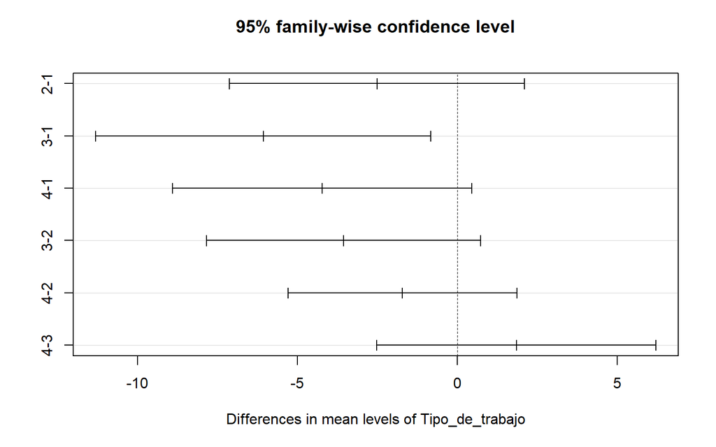

```r
plot(TukeyHSD(ANOVA_SatifLab, "Tipo_de_trabajo"))
```

```r
describe.by(BaseTrabajo$Satisfaccion_laboral, BaseTrabajo$Tipo_de_trabajo)
```

```
##
##  Descriptive statistics by group
## group: 1
##    vars  n  mean   sd median trimmed  mad   min   max range skew kurtosis   se
## X1    1 43 53.33 9.02   53.2   52.93 8.28 36.24 73.78 37.54 0.38    -0.47 1.38
## ------------------------------------------------------------
## group: 2
##    vars   n  mean   sd median trimmed   mad   min   max range  skew kurtosis
## X1    1 107 50.82 10.5  49.84   50.97 10.98 19.52 78.24 58.73 -0.13     0.09
##      se
## X1 1.02
## ------------------------------------------------------------
## group: 3
##    vars  n  mean   sd median trimmed  mad   min   max range skew kurtosis   se
## X1    1 53 47.27 9.59  47.13   47.18 8.68 26.64 81.28 54.64 0.47     1.55 1.32
## ------------------------------------------------------------
## group: 4
##    vars  n  mean   sd median trimmed  mad   min   max range skew kurtosis   se
## X1    1 97 49.11 9.68  47.65   48.94 8.47 27.02 72.47 45.45 0.19    -0.12 0.98
```

> **Since the assumption of normality is met for all four groups and the assumption of homogeneity of variances, a one-way ANOVA was conducted.**  
> **A main effect of the job type variable on job satisfaction scores was found (F(3, 296) = 3.50, p = .016, η² = .03). The post-hoc Tukey test revealed that individuals working in customer service have significantly lower job satisfaction levels compared to those in marketing (p < .05). No significant differences were found in the other comparisons.**

# 8. The goal is to analyze the best predictors of job satisfaction (“Satisfaccion_laboral”). For this, the following variables are proposed as possible predictors: “Cognitive_flexibility,” “Work_environment_perception,” “Self_esteem,” “Future_job_outlook,” “Anxiety,” “Depression,” “Intelligence,” and “Social_network.”

## a. What is the level of linear association between the proposed predictor variables and job satisfaction? Evaluate both numerically and graphically.

### Correlation between job satisfaction and cognitive flexibility.

```r
cor.test(BaseTrabajo$Satisfaccion_laboral, BaseTrabajo$Flexibilidad_cognitiva, method = "pearson")
```

```
##
##  Pearson's product-moment correlation
##
## data:  BaseTrabajo$Satisfaccion_laboral and BaseTrabajo$Flexibilidad_cognitiva
## t = 12.947, df = 298, p-value < 2.2e-16
## alternative hypothesis: true correlation is not equal to 0
## 95 percent confidence interval:
##  0.5222427 0.6678632
## sample estimates:
## cor
## 0.6
```

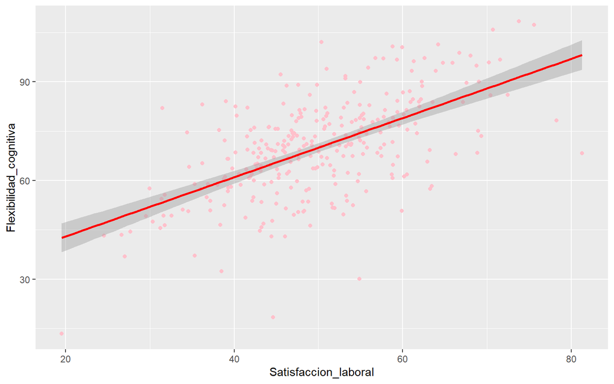

```r
ggplot(BaseTrabajo, aes(x=Satisfaccion_laboral, y=Flexibilidad_cognitiva)) +
  geom_point(color = "pink") +
  geom_smooth(method="lm", color = "red")
```

> **A positive and moderately strong correlation between job satisfaction and cognitive flexibility was found (r(298) = .6, p < .001). This means that as cognitive flexibility increases, job satisfaction tends to increase as well.**

### Correlation between job satisfaction and work environment perception.

```r
cor.test(BaseTrabajo$Satisfaccion_laboral, BaseTrabajo$Percepcion_ambiente_laboral, method = "pearson")
```

```
##
##  Pearson's product-moment correlation
##
## data:  BaseTrabajo$Satisfaccion_laboral and BaseTrabajo$Percepcion_ambiente_laboral
## t = 7.534, df = 298, p-value = 5.926e-13
## alternative hypothesis: true correlation is not equal to 0
## 95 percent confidence interval:
##  0.3003646 0.4910003
## sample estimates:
## cor
## 0.4
```

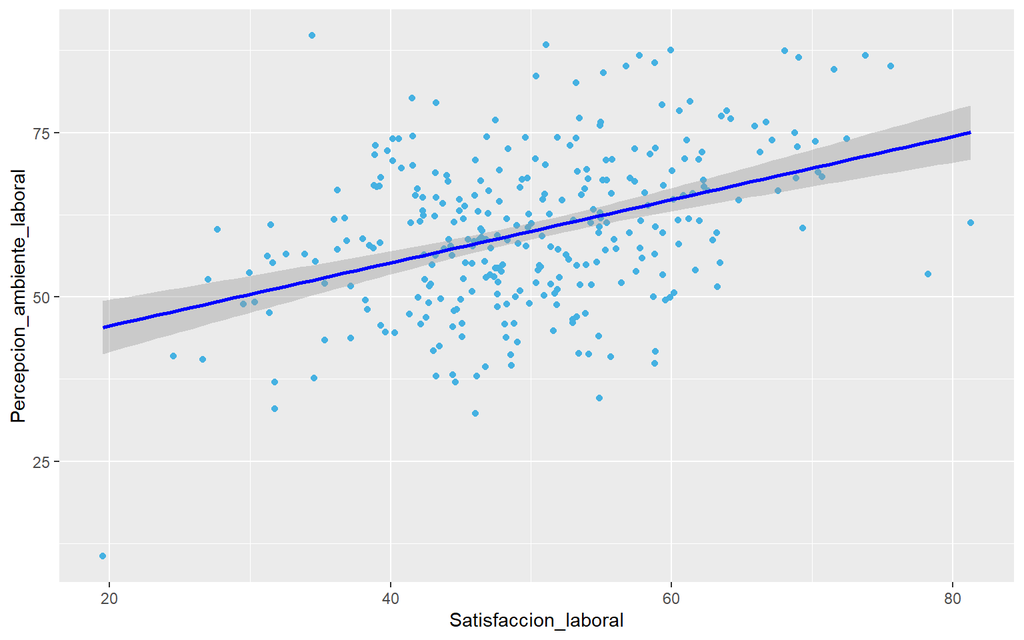

```r
ggplot(BaseTrabajo, aes(x=Satisfaccion_laboral, y=Percepcion_ambiente_laboral)) +
  geom_point(color = "#45B1E2") +
  geom_smooth(method="lm", color = "blue")
```

> **A positive and moderate correlation between job satisfaction and work environment perception was found (r(298) = .4, p < .001). This means that as the perception of the work environment increases, job satisfaction also tends to increase.**

### Correlation between job satisfaction and self-esteem.

```r
cor.test(BaseTrabajo$Satisfaccion_laboral, BaseTrabajo$Autoestima, method = "pearson")
```

```
##
##  Pearson's product-moment correlation
##
## data:  BaseTrabajo$Satisfaccion_laboral and BaseTrabajo$Autoestima
## t = 5.4289, df = 298, p-value = 1.177e-07
## alternative hypothesis: true correlation is not equal to 0
## 95 percent confidence interval:
##  0.1933269 0.3996634
## sample estimates:
## cor
## 0.3
```

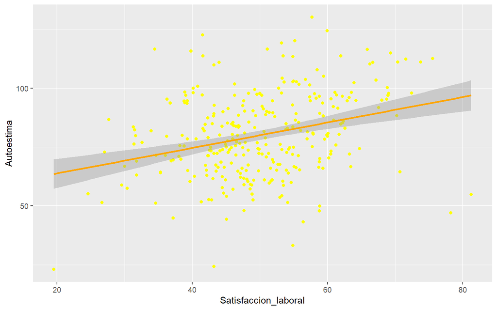

```r
ggplot(BaseTrabajo, aes(x=Satisfaccion_laboral, y=Autoestima)) +
  geom_point(color = "yellow") +
  geom_smooth(method="lm", color = "orange")
```

> **A positive and moderately low correlation between job satisfaction and self-esteem was found (r(298) = .3, p < .001). This means that as self-esteem increases, job satisfaction also tends to increase.**

### Correlation between job satisfaction and future job outlook.

```r
cor.test(BaseTrabajo$Satisfaccion_laboral, BaseTrabajo$Perspectiva_laboral_futura, method = "pearson")
```

```
##
##  Pearson's product-moment correlation
##
## data:  BaseTrabajo$Satisfaccion_laboral and BaseTrabajo$Perspectiva_laboral_futura
## t = 9.9666, df = 298, p-value < 2.2e-16
## alternative hypothesis: true correlation is not equal to 0
## 95 percent confidence interval:
##  0.4099719 0.5803795
## sample estimates:
## cor
## 0.5
```

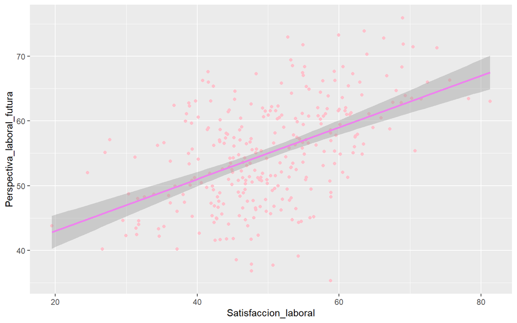

```r
ggplot(BaseTrabajo, aes(x=Satisfaccion_laboral, y=Perspectiva_laboral_futura)) +
  geom_point(color = "pink") +
  geom_smooth(method="lm", color = "violet")
```

> **A positive and moderately strong correlation between job satisfaction and future job outlook was found (r(298) = .5, p < .001). This means that as future job outlook increases, job satisfaction also tends to increase.**

### Correlation between job satisfaction and anxiety.

```r
cor.test(BaseTrabajo$Satisfaccion_laboral, BaseTrabajo$Ansiedad, method = "pearson")
```

```
##
##  Pearson's product-moment correlation
##
## data:  BaseTrabajo$Satisfaccion_laboral and BaseTrabajo$Ansiedad
## t = 3.5237, df = 298, p-value = 0.0004923
## alternative hypothesis: true correlation is not equal to 0
## 95 percent confidence interval:
##  0.08876963 0.30630362
## sample estimates:
## cor
## 0.2
```

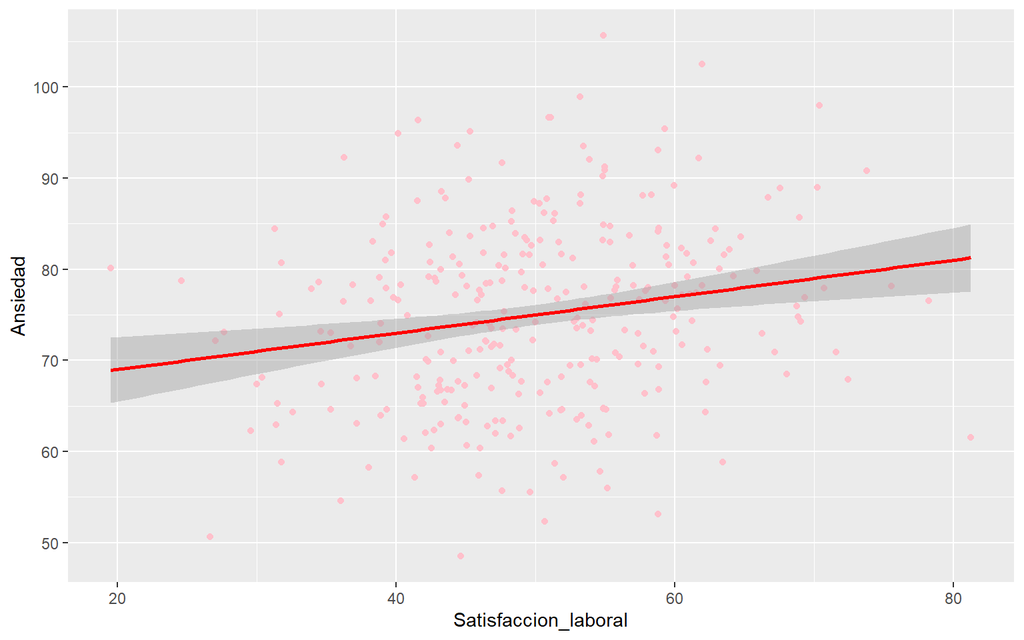

```r
ggplot(BaseTrabajo, aes(x=Satisfaccion_laboral, y=Ansiedad)) +
  geom_point(color = "pink") +
  geom_smooth(method="lm", color = "red")
```

> **A positive and low correlation between job satisfaction and anxiety was found (r(298) = .2, p < .001). This means that as anxiety increases, job satisfaction also tends to increase.**

### Correlation between job satisfaction and depression.

```r
cor.test(BaseTrabajo$Satisfaccion_laboral, BaseTrabajo$Depresion, method = "pearson")
```

```
##
##  Pearson's product-moment correlation
##
## data:  BaseTrabajo$Satisfaccion_laboral and BaseTrabajo$Depresion
## t = 5.4289, df = 298, p-value = 1.177e-07
## alternative hypothesis: true correlation is not equal to 0
## 95 percent confidence interval:
##  0.1933269 0.3996634
## sample estimates:
## cor
## 0.3
```

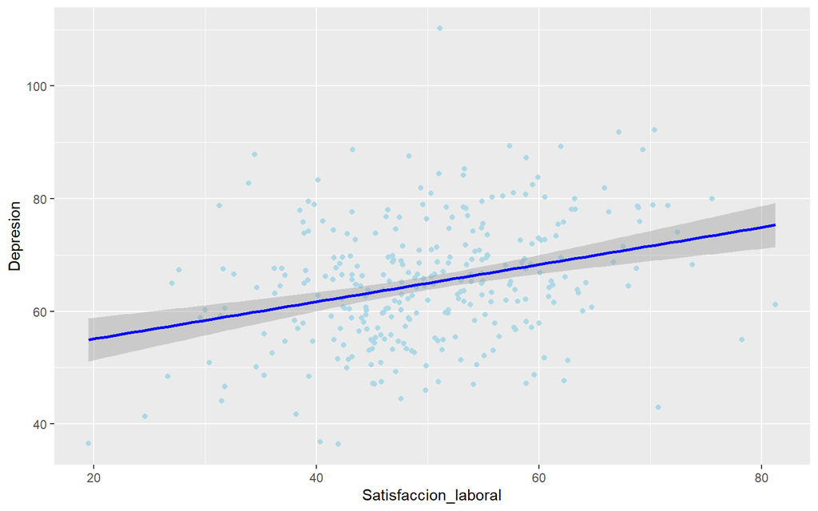

```r
ggplot(BaseTrabajo, aes(x=Satisfaccion_laboral, y=Depresion)) +
  geom_point(color = "lightblue") +
  geom_smooth(method="lm", color = "blue")
```

> **A positive and moderately low correlation between job satisfaction and depression was found (r(298) = 0.3, p < .001). This means that as depression increases, job satisfaction also tends to increase.**

### Correlation between job satisfaction and intelligence.

```r
cor.test(BaseTrabajo$Satisfaccion_laboral, BaseTrabajo$Inteligencia, method = "pearson")
```

```
##
##  Pearson's product-moment correlation
##
## data:  BaseTrabajo$Satisfaccion_laboral and BaseTrabajo$Inteligencia
## t = 0.071151, df = 298, p-value = 0.9433
## alternative hypothesis: true correlation is not equal to 0
## 95 percent confidence interval:
##  -0.1091702  0.1173077
## sample estimates:
##         cor
## 0.004121624
```

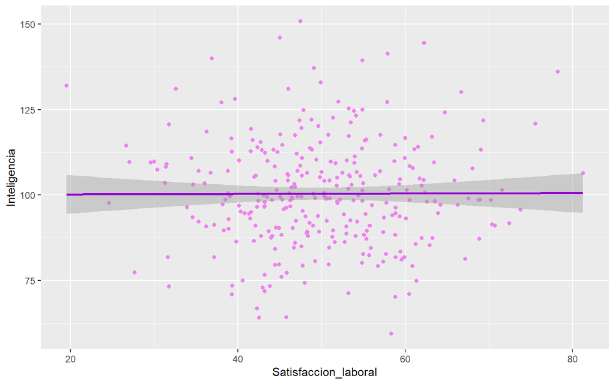

```r
ggplot(BaseTrabajo, aes(x=Satisfaccion_laboral, y=Inteligencia)) +
  geom_point(color = "violet") +
  geom_smooth(method="lm", color = "darkviolet")
```

> **No association was found between the variables job satisfaction and intelligence.**

### Correlation between job satisfaction and social network.

```r
cor.test(BaseTrabajo$Satisfaccion_laboral, BaseTrabajo$Red_social, method = "pearson")
```

```
##
##  Pearson's product-moment correlation
##
## data:  BaseTrabajo$Satisfaccion_laboral and BaseTrabajo$Red_social
## t = -1.1217, df = 298, p-value = 0.2629
## alternative hypothesis: true correlation is not equal to 0
## 95 percent confidence interval:
##  -0.17678363  0.04875801
## sample estimates:
##         cor
## -0.06484084
```

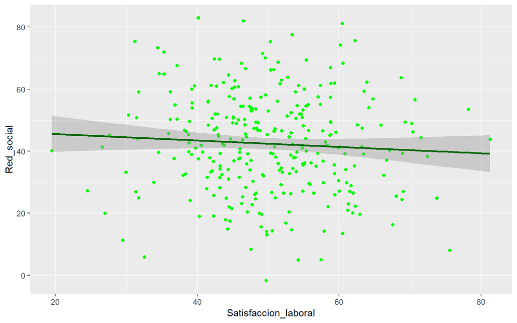

```r
ggplot(BaseTrabajo, aes(x=Satisfaccion_laboral, y=Red_social)) +
  geom_point(color = "green") +
  geom_smooth(method="lm", color = "darkgreen")
```

> **No association was found between the variables job satisfaction and social network.**